# a3

Haozhe Cui

## Introduction

One of the sharpest manifestations of racism in the United States is its prison system. By exploring incarceration_trends data, we can use R to analyze whether inequality occurs between black and white. In this practice, I will focus on the jail and prison populations to explore this phenomenon.

In my summary statistic page, I first calculate the total population between 2008 to 2018 to use the most recent data information to analyze. Then, by calculating the mean of some of the population in each state, I get the five most populated states between 2008 to 2018, and they are VT, WI, WY, WA, and WV. I want to use these top 5 states to analyze because they can highlight the most obvious question I want. Finally, by calculating the ratio between the white and black population in the jail and prison in these five states between 2008 to 2018, I find the black percentage in the jail and prison is much higher than the white. (jail_ratio between black and white: 359.2596 and inf, prison_ration between black and white:192.2482 and inf)

## Chart 1

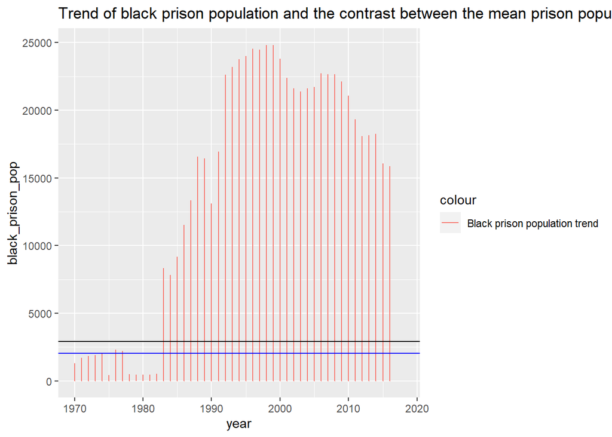

[figure not shown]

## Chart 3

This chart is intended to show the distribution of total jail population in Washington state. By demonstrating the distribution, we could efficiently focus on places where have the most total jail population to effectively analyze the existence of ineuqaility between black and white.

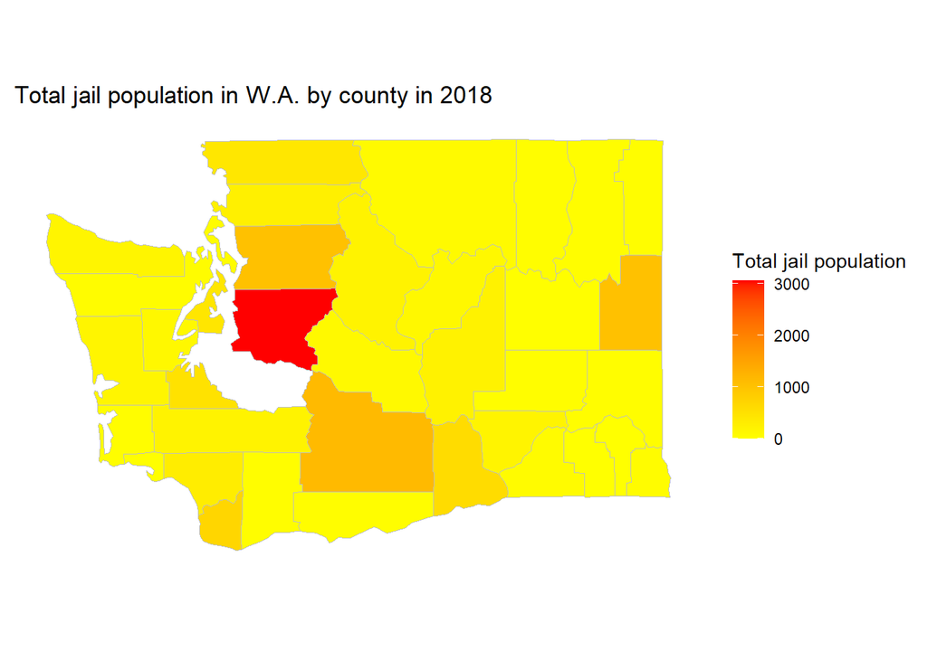